# Stacking Ensemble Regression Approach with RFE and Genetic Algorithm Feature Selection for Quantifying Coffee Adulteration: Spectral Preprocessing Using MSC, Savitzky-Golay, and First Derivative

Author

Derick Malavi

## Introduction

Coffee adulteration, such as blending premium Arabica with lower-cost Robusta, undermines quality and authenticity, posing significant challenges for consumers, producers, and regulators. High-dimensional spectroscopic data provides valuable insights for detecting such fraud, but the large number of variables necessitates effective feature selection techniques to isolate the most relevant wavelengths.

This study combines Recursive Feature Elimination (RFE) and Genetic Algorithm (GA) to identify the most critical spectral features for predicting coffee adulteration. These methods complement each other by ensuring the selection of non-redundant, high-impact features, which are crucial for optimizing model accuracy and interpretability.

Regression is then performed by stacking ensemble approach that integrates Partial Least Squares (PLS), Elastic Net, and Lasso regressions, with Random Forest (RF) as the meta-learner. Elastic Net regression, a robust technique combining L1 (Lasso) and L2 (Ridge) regularizations, addresses multicollinearity while selecting key spectral features. The stacking approach leverages the individual strengths of these models, with the meta-learner aggregating their predictions to achieve efficient modeling of high-dimensional spectral data, reduce redundancy, and improve prediction accuracy.

```r
# Load libraries
warning = FALSE
  suppressWarnings(suppressMessages({
  library(caret)
  library(caretEnsemble)
  library(GA)
  library(glmnet)
  library(viridis)
  library(Boruta)
  library(ggplot2)
  library(dplyr)
  library(readxl)
  library(readr)
  library(janitor)
  library(class)
  library(MLmetrics)
  library(MLeval)
  library(themis)
  library(ROSE)
  library(parallel)
  library(doParallel)
  library(foreach)
  library(pheatmap)
  library(mdatools)
  library(nnet)
  library(DMwR)
  library(e1071)
  library(knitr)
  library(pROC)
  library(gridExtra)
  library(FactoMineR)
  library(doSNOW)
  library(MASS)
  library(factoextra)
  library(kernlab)}))
```

## Prepare Data

```r
# Load data: msc_sg_1d spectra

hsi_msc_sg_1d <- read.csv("coffee_ground_msc_sg_1d.csv")

# Ensure we have the same number of dimensions and the range of our columns/covariates
dim(hsi_msc_sg_1d)
```

```
[1] 1469  229
```

```r
# Check a few column names
col_check <- colnames(hsi_msc_sg_1d[,c(1:6)])
col_check
```

```
[1] "sample_id"     "binary_class"  "three_class"   "adult_percent"
[5] "cal_val"       "X935.609985"
```

```r
# our response variable (adulteration percentage) is column 4
# The spectral values start from column # 6 -------> 229

# Convert the adulteration percentage to numeric for compatibility with ML
hsi_msc_sg_1d$adult_percent <- as.numeric(hsi_msc_sg_1d$adult_percent)
```

## Get the X and y variables

```r
X <- hsi_msc_sg_1d[,c(6:229)]
y <- hsi_msc_sg_1d[,4]

class(y) #Ensure y (target variable) is a numeric for regression
```

```
[1] "numeric"
```

## Visualize X

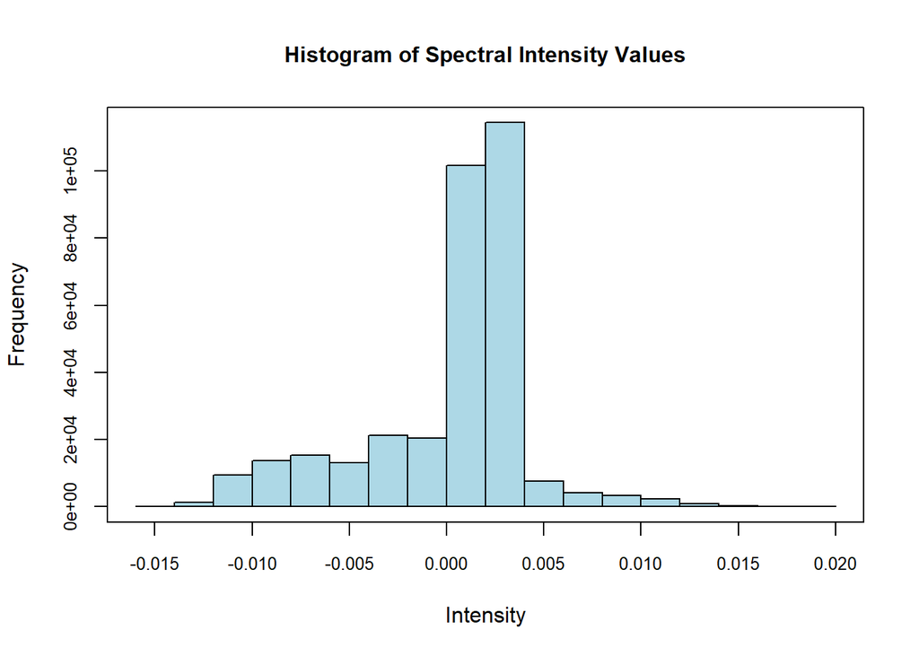

```r
hist(as.matrix(X), col = 'lightblue', cex.main = 1.0, cex.axis = 0.8,cex.lab = 1.0,
     main = 'Histogram of Spectral Intensity Values', xlab = 'Intensity'); box()
```

## Split the Data (Train_Test Split)

- We want to select features based on training data only to avoid any data leakage that could inflate model performance and make the model less generalizable to unseen data.

```r
# Subset samples for cross-validation and external validation (70/30)
# Record 1 under cal_val variable is for calibration while 2 will be for testing the model

sample<-hsi_msc_sg_1d$cal_val == 1

# Split to train and test sets
X_train <- X[sample,]
X_test <- X[!sample,]
y_train <-y[sample]
y_test <- y[!sample]

# Check length of the subsets for training and validation
dim(X_train)
```

```
[1] 1055  224
```

```r
dim(X_test)
```

```
[1] 414 224
```

```r
length(y_train)
```

```
[1] 1055
```

```r
length(y_test)
```

```
[1] 414
```

```r
# Merge the test and train data
train_data <- data.frame(X_train, y_train)
test_data <- data.frame(X_test, y_test)
```

## Define the Fitness Function for GA

- This function evaluates subsets of features selected by GA using RFE with a Random Forest (RF) model.

```r
# Fitness Function for RMSE
fitness_ga_rfe <- function(subset) {
  # Identify selected features based on the binary subset
  selected_features <- which(subset == 1)

  # Penalize empty subsets to avoid errors
  if (length(selected_features) == 0) return(Inf)

  # Subset the training feature matrix to selected features
  X_selected <- X_train[, selected_features]

  # Define control for RFE
  control <- rfeControl(functions = rfFuncs,
                        method = "cv",
                        number = 10)

  # Apply RFE to the selected subset of features
  rfe_result <- rfe(X_selected, y_train, rfeControl = control, metric = "RMSE")

  # Return the RMSE as the fitness score (lower is better)
  return(min(rfe_result$results$RMSE))
}
```

```r
# Set seed for reproducibility
set.seed(123)

num_features <- ncol(X_train) # Number of features
dataset_name <- "msc_sg_1d"   # Set the dataset name dynamically

# Define paths for the execution flag and GA result
flag_file <- paste0("ga_executed_flag_", dataset_name, ".RData")
result_file <- paste0("ga_result_", dataset_name, ".RData")

# Check if the result file exists
if (!file.exists(result_file)) {
  message("No result file found. Running the Genetic Algorithm (GA).")

  # Register cluster for caret to train the models in parallel
  cl <- makeCluster(6, type = "SOCK")
  suppressWarnings(suppressMessages(registerDoSNOW(cl)))

  # Register start time
  start_time <- Sys.time()

  # Run the Genetic Algorithm
  ga_result <- ga(
    type = "binary",
    fitness = fitness_ga_rfe,
    nBits = num_features,             # Number of features
    popSize = 20,                     # Population size
    maxiter = 50,                     # Maximum iterations
    run = 10,                         # Convergence stopping criterion
    names = colnames(train_data[, -ncol(train_data)]),  # Feature names
    pcrossover = 0.8,                 # Probability of crossover
    pmutation = 0.1,                  # Probability of mutation
    parallel = TRUE,                  # Enable parallel processing
    monitor = gaMonitor,              # Track progress
    seed = 123                        # Reproducibility
  )

  # Stop the cluster
  stopCluster(cl)

  # Register end time
  end_time <- Sys.time()
  print(paste('Time to run the GA model:', end_time - start_time))

  # Save the GA result and execution flag
  ga_executed <- TRUE
  save(ga_executed, ga_result, file = result_file)  # Save both flag and results

  message("GA execution completed and results saved.")

} else {
  # Load previously saved results
  message("Result file found. Loading saved GA results.")
  load(result_file)
  message(paste("GA already executed for dataset:", dataset_name))
}
```

```
Result file found. Loading saved GA results.
```

```
GA already executed for dataset: msc_sg_1d
```

## Visualization Plot

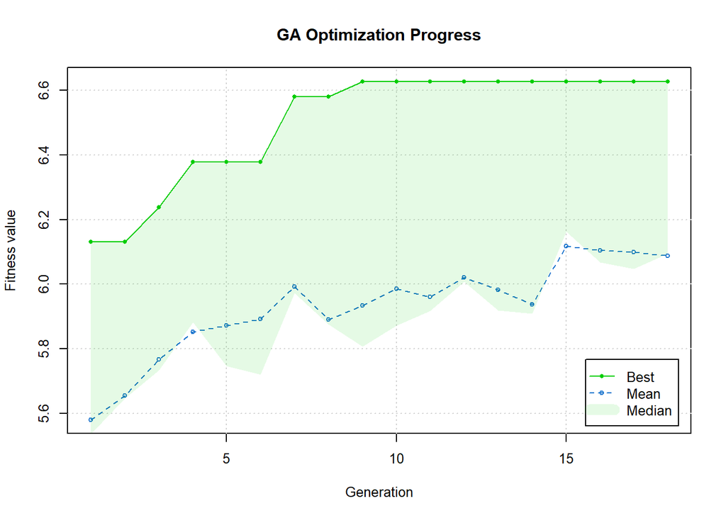

```r
par (cex = 0.8)
plot(ga_result, main = "GA Optimization Progress")
```

```r
par(cex = 1)
```

## Analyze GA results

```r
summary(ga_result)
```

```
── Genetic Algorithm ───────────────────

GA settings:
Type                  =  binary
Population size       =  20
Number of generations =  50
Elitism               =  1
Crossover probability =  0.8
Mutation probability  =  0.1

GA results:
Iterations             = 18
Fitness function value = 6.627592
Solution =
     X935.609985 X939.059998 X942.52002 X945.97998 X949.429993 X952.890015
[1,]           1           0          0          1           1           0
     X956.349976 X959.809998 X963.27002 X966.72998  ...  X1716.650024
[1,]           0           0          0          1                  1
     X1720.22998
[1,]           0
```

## Post-Selection

```r
# Get the best feature subset
best_features <- which(ga_result@solution == 1)
selected_feature_names <- colnames(train_data)[best_features]
print(selected_feature_names)
```

```
  [1] "X935.609985"  "X945.97998"   "X949.429993"  "X966.72998"   "X970.190002"
  [6] "X973.650024"  "X984.039978"  "X987.51001"   "X990.969971"  "X994.429993"
 [11] "X997.900024"  "X1018.710022" "X1025.650024" "X1029.119995" "X1032.589966"
 [16] "X1049.949951" "X1053.430054" "X1056.900024" "X1063.849976" "X1077.76001"
 [21] "X1081.23999"  "X1084.719971" "X1088.199951" "X1091.680054" "X1095.170044"
 [26] "X1098.650024" "X1102.130005" "X1112.579956" "X1116.069946" "X1126.52002"
 [31] "X1130.01001"  "X1133.5"      "X1147.449951" "X1157.930054" "X1161.420044"
 [36] "X1171.900024" "X1175.390015" "X1178.890015" "X1182.380005" "X1185.880005"
 [41] "X1196.369995" "X1199.869995" "X1206.869995" "X1210.369995" "X1213.869995"
 [46] "X1220.869995" "X1231.380005" "X1234.880005" "X1238.390015" "X1248.900024"
 [51] "X1252.410034" "X1259.420044" "X1266.439941" "X1280.47998"  "X1283.98999"
 [56] "X1287.51001"  "X1298.050049" "X1312.109985" "X1319.140015" "X1322.660034"
 [61] "X1333.219971" "X1340.26001"  "X1343.780029" "X1347.300049" "X1350.819946"
 [66] "X1354.349976" "X1357.869995" "X1364.920044" "X1371.969971" "X1375.5"
 [71] "X1382.550049" "X1386.079956" "X1389.609985" "X1393.140015" "X1403.72998"
 [76] "X1410.790039" "X1421.390015" "X1424.920044" "X1428.459961" "X1431.98999"
 [81] "X1439.069946" "X1449.680054" "X1453.219971" "X1456.76001"  "X1460.300049"
 [86] "X1463.839966" "X1467.380005" "X1470.920044" "X1481.550049" "X1485.089966"
 [91] "X1488.640015" "X1517.01001"  "X1520.560059" "X1524.109985" "X1545.420044"
 [96] "X1552.530029" "X1556.089966" "X1559.640015" "X1563.199951" "X1570.310059"
[101] "X1573.869995" "X1584.550049" "X1588.109985" "X1591.670044" "X1602.349976"
[106] "X1605.920044" "X1613.040039" "X1620.170044" "X1623.73999"  "X1630.869995"
[111] "X1638.01001"  "X1645.150024" "X1652.290039" "X1677.290039" "X1702.329956"
[116] "X1713.069946" "X1716.650024"
```

```r
print(paste('The number of selected variables are', length(selected_feature_names)))
```

```
[1] "The number of selected variables are 117"
```

```r
n_selected <- as.numeric(length(selected_feature_names))
```

## Create a Data frame with the Selected Features

```r
# Subset the training and test data using the selected features
X_train_selected <- X_train[, selected_feature_names]
X_test_selected <- X_test[, selected_feature_names]

# Keep y_train and y_test as-is
y_train_selected <- y_train
y_test_selected <- y_test

#Merge data_frame
train_merged <- cbind(y_train = y_train_selected, X_train_selected)
test_merged <- cbind(y_test = y_test_selected, X_test_selected)

dim(train_merged)
```

```
[1] 1055  118
```

```r
dim(test_merged)
```

```
[1] 414 118
```

## Check correlations by HeatMaps

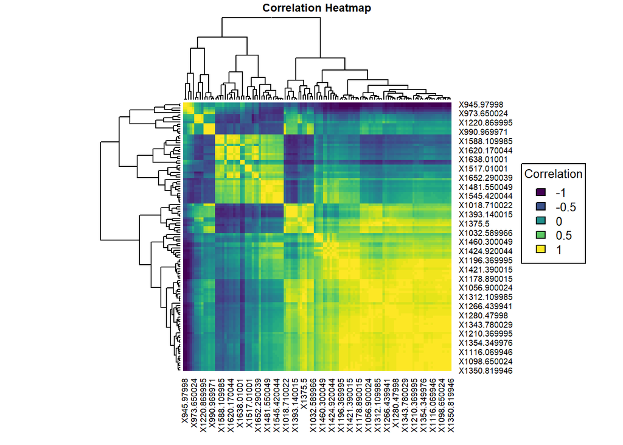

```r
n_features <- length(n_selected)

#Calculate correlations
corr <- cor(train_merged[, -(n_features+1)])

# Create a heat map
par(cex.main = 0.6)
heatmap(corr, symm = TRUE,
        col = viridis(50),
        main = "Correlation Heatmap")

# Add legend

legend("right",
       legend = seq(-1, 1, by = 0.5),  # Correlation range
       fill = viridis(5),
       title = "Correlation", cex = 0.8)
```

## Train Models

```r
# Set random seed for reproducibility
set.seed (123)

# Set up the training control(10 folds 10 times cross_validation)
control <- trainControl(method = "repeatedcv", number = 10, repeats = 10,
                        savePredictions = "final",
                        summaryFunction = defaultSummary,
                        selectionFunction = 'best', allowParallel = TRUE)

# We used oneSE for classification. For regression, we will use 'best': a model that minimizes RMSECV
```

```r
#Set the metric as accuracy
metric<-"RMSE"
```

```r
# Hyperparameter set Elastic Net Regression
# alpha: Set for L1(elastic_net) and L2(Ridge) Regression
# lambda: Regularization strength (penalty parameter). A sequence of values is tested to identify the best lambda.

grid_enet <- expand.grid( alpha = seq(0, 1, length = 10),  # Explore between Ridge (alpha = 0) and elastic_net (alpha = 1)
    lambda = seq(0.001, 0.1, length = 10))

# alpha: Set to 1 for LASSO (pure L1 regularization).
# lambda: Regularization strength (penalty parameter). A sequence of values is tested to identify the best lambda.

grid_lasso <- expand.grid(
  alpha = 1,   # LASSO (alpha = 1)
  lambda = seq(0.001, 0.1, length = 10)
)

# PLS grid for determining optimal number of LVs (pls components)
grid_pls <- expand.grid(.ncomp = seq(1,60, by =1))
```

# Train Base Learners (Lasso, Elastic Net PLS)

```r
set.seed(123)
#Register cluster for caret to train the models in parallel
cl<-makeCluster(6,type = "SOCK")
suppressWarnings(suppressMessages(
  registerDoSNOW(cl)))

# Start_time
start_time<-Sys.time()

#Train the model using cross-validation (10 folds, 10 times)
fit_enet_msc_sg_1d<-train(y = train_merged[,1],
                         x = train_merged[,-1],
                         method = 'glmnet', tuneGrid = grid_enet,
                         trControl = control, preProcess = c("center","scale"),
                         metric = metric)

fit_lasso_msc_sg_1d<-train(y = train_merged[,1],
                         x = train_merged[,-1],
                         method = 'glmnet', tuneGrid = grid_lasso,
                         trControl = control, preProcess = c("center","scale"),
                         metric = metric)


fit_pls_msc_sg_1d<-train(y = train_merged[,1],
                         x = train_merged[,-1],
                         method = 'pls', tuneGrid = grid_pls,
                         trControl = control, preProcess = c("center","scale"),
                         metric = metric)
#End_time
end_time<-Sys.time()

model_training_time<-end_time-start_time

stopCluster(cl) # Stop the parallel run cluster

print(model_training_time)
```

```
Time difference of 2.365144 mins
```

```r
# Make list for the trained models (base learners)

model_list <- list(pls = fit_pls_msc_sg_1d,
                   enet = fit_enet_msc_sg_1d,
                   lasso = fit_lasso_msc_sg_1d)

# Stack the models and feed the predictions from cross-validations to a meta-learner (Random Forest)

set.seed(123)
cl<-makeCluster(6,type = "SOCK")
suppressWarnings(suppressMessages(
  registerDoSNOW(cl)))

# Start_time
start_time<-Sys.time()


fit_stack_ensemble_msc_sg_1d <- caretStack(model_list, method = 'rf', metric = metric,
                                       trControl = control,tuneLength = 10)
#End_time
end_time<-Sys.time()
model_training_time<-end_time-start_time
stopCluster(cl) # Stop the parallel run cluster

print(model_training_time)
```

```
Time difference of 1.351442 mins
```

```r
# Display regression results
print(fit_stack_ensemble_msc_sg_1d)
```

```
The following models were ensembled: pls, enet, lasso

caret::train model:
Random Forest

1055 samples
   3 predictor

No pre-processing
Resampling: Cross-Validated (10 fold, repeated 10 times)
Summary of sample sizes: 949, 949, 949, 948, 949, 950, ...
Resampling results across tuning parameters:

  mtry  RMSE      Rsquared   MAE
  2     5.058113  0.9693543  3.133930
  3     5.119937  0.9686375  3.113731

RMSE was used to select the optimal model using the smallest value.
The final value used for the model was mtry = 2.

Final model:

Call:
 randomForest(x = x, y = y, mtry = param$mtry)
               Type of random forest: regression
                     Number of trees: 500
No. of variables tried at each split: 2

          Mean of squared residuals: 25.64062
                    % Var explained: 96.9
```

#### Best hyperparameters

```r
# Optimal values
fit_stack_ensemble_msc_sg_1d$ens_model$bestTune
```

```
  mtry
1    2
```

## Save the models for future use

```r
saveRDS(fit_stack_ensemble_msc_sg_1d, "fit_stack_ensemble_msc_sg_1d.rds")
```

## Display CV Results in Tables

```r
kable(fit_stack_ensemble_msc_sg_1d$ens_model$results)
```

| mtry | RMSE | Rsquared | MAE | RMSESD | RsquaredSD | MAESD |
| --- | --- | --- | --- | --- | --- | --- |
| 2 | 5.058113 | 0.9693543 | 3.133930 | 0.5300555 | 0.0060857 | 0.3557844 |
| 3 | 5.119937 | 0.9686375 | 3.113731 | 0.5292096 | 0.0061818 | 0.3688919 |

```r
# Select row for the optimal model
opt_row <- fit_stack_ensemble_msc_sg_1d$ens_model$results%>%
  filter(mtry==fit_stack_ensemble_msc_sg_1d$ens_model$bestTune$mtry)

kable(opt_row)
```

| mtry | RMSE | Rsquared | MAE | RMSESD | RsquaredSD | MAESD |
| --- | --- | --- | --- | --- | --- | --- |
| 2 | 5.058113 | 0.9693543 | 3.13393 | 0.5300555 | 0.0060857 | 0.3557844 |

## Test the model performance on test data

```r
#Predict on the test set
observed <- test_merged$y_test
predictions <- predict(fit_stack_ensemble_msc_sg_1d,newdata=test_merged)

# Generate predictions
results <- postResample(predictions, observed)

print(results)
```

```
     RMSE  Rsquared       MAE
9.0039900 0.9160936 6.5631911
```

```r
RMSEP = results[[1]]
R2 = results[[2]]
MAE = results[[3]]

cat('The RMSEP for the model on external validation is:', RMSEP,'\n')
```

```
The RMSEP for the model on external validation is: 9.00399
```

```r
cat('The R Squared value for the model is:', R2)
```

```
The R Squared value for the model is: 0.9160936
```

```r
# Calculate Residual Predictive Deviation to check model performance

RPD = sd(observed)/RMSEP

print(paste('The RPD values for the model is', round(RPD,2)))
```

```
[1] "The RPD values for the model is 3.23"
```

## Conclusion

- Stacked models demonstrate excellent performance in predicting adulteration in ground coffee. The model achieves an RPD value of 3.2. The model can make reliable predictions and is suitable for quality control.